```python
import numpy as np
import pandas as pd
import matplotlib.pyplot as plt
import seaborn as sns
sns.set_theme()
plt.rcParams['text.usetex'] = False
```

# Introduction to Numpy

Numpy, or Numerical Python is a python package for scientific computing, that finds wide usage in almost any application involving math and scientific stuff. We are going to discuss what are numpy arrays, how to create them, how they behave, and we will then perform some basic arithmetic with them.

## Array creation

```python
# converting an existing python list to array
np.array([1,2,3])
```

```
array([1, 2, 3])
```

```python
# Similar to the inbuilt range function in python, numpy has the arange function.
np.arange(5)
np.arange(1,5)
np.arange(1,10,2)
```

```
array([1, 3, 5, 7, 9])
```

```python
# we can also create an array of linearly spaced values within a specific range.
np.linspace(5, 10, 20)
```

```
array([ 5.        ,  5.26315789,  5.52631579,  5.78947368,  6.05263158,
        6.31578947,  6.57894737,  6.84210526,  7.10526316,  7.36842105,
        7.63157895,  7.89473684,  8.15789474,  8.42105263,  8.68421053,
        8.94736842,  9.21052632,  9.47368421,  9.73684211, 10.        ])
```

```python
# creates an array of only 0's of the specified shape
print(np.zeros(shape=10))
print(np.zeros(shape=(2,2)))
```

```
[0. 0. 0. 0. 0. 0. 0. 0. 0. 0.]
[[0. 0.]
 [0. 0.]]
```

```python
# similar to above creates an array of only 1's
print(np.ones(shape=5))
print(np.ones(shape=(2,2)))
```

```
[1. 1. 1. 1. 1.]
[[1. 1.]
 [1. 1.]]
```

```python
# now we will look at generating an array of random numbers with numpy.

# np.random.randint creates an array of random integers from a given range.
np.random.randint(10, 50, size=10)
np.random.randint(10, 50, size=(2,5))
```

```
array([[48, 14, 45, 49, 35],
       [46, 17, 31, 21, 23]])
```

```python
#np.randomm.random creates an array of random real numbers in [0.0, 1.0)].
np.random.random(size=10)
np.random.random(size=(2,5))
```

```
array([[0.02953565, 0.0542713 , 0.91625215, 0.48201435, 0.47026242],
       [0.3647718 , 0.64692046, 0.91274573, 0.29853519, 0.69791224]])
```

## Slicing and Indexing

Now that we have created our brand new numpy array, we need to understand how to use it, that is, how to access elements from it, how to modify the entries in it.

```python
x = np.arange(10)
y = np.random.randint(0, 9, size=(5,5))
```

Indexing an array essentially means obtaining an element from it. The good thing is, numpy arrays can be indexed exactly like python lists. So its nothing new!

```python
x
```

```
array([0, 1, 2, 3, 4, 5, 6, 7, 8, 9])
```

```python
y
```

```
array([[2, 2, 8, 6, 0],
       [6, 4, 7, 4, 1],
       [5, 3, 0, 3, 2],
       [5, 2, 2, 2, 8],
       [5, 2, 5, 5, 3]])
```

```python
x[4]
```

```
4
```

```python
y[2]
```

```
array([5, 3, 0, 3, 2])
```

```python
y[1,1]
```

```
4
```

What will be somewhat new, is slicing.

```python
print(x[:5])
print(x[5:])
print(x[2:5])
```

```
[0 1 2 3 4]
[5 6 7 8 9]
[2 3 4]
```

```python
print(y[:,1])
print(y[1,:]) #same as y[1]
print(y[1:3, 1:3])
```

```
[2 4 3 2 2]
[6 4 7 4 1]
[[4 7]
 [3 0]]
```

```python
x[2:5] = 3
x
```

```
array([0, 1, 3, 3, 3, 5, 6, 7, 8, 9])
```

## Arithmetic with these arrays

In maths, we generally add two matrices pretty easily. In python any kind of arithmetic operations on lists, like addition, subtraction, scalar multiplication, involviing loops usually are veeerrryyy slow. Numpy makes them faster. Numpy does vectorized operations on arrays which are extremely fast.

```python
a = np.random.randint(1,9, size=10)
b = np.random.randint(1,9, size=10)
```

```python
a
```

```
array([7, 6, 1, 5, 7, 4, 2, 2, 8, 6])
```

```python
b
```

```
array([7, 6, 1, 1, 1, 4, 8, 3, 8, 7])
```

```python
a+b
```

```
array([14, 12,  2,  6,  8,  8, 10,  5, 16, 13])
```

```python
1/a
```

```
array([0.14285714, 0.16666667, 1.        , 0.2       , 0.14285714,
       0.25      , 0.5       , 0.5       , 0.125     , 0.16666667])
```

```python
4*b
```

```
array([28, 24,  4,  4,  4, 16, 32, 12, 32, 28])
```

## some important numpy functions

```python
np.pi
```

```
3.141592653589793
```

```python
np.exp
```

```
<ufunc 'exp'>
```

```python
np.inf
```

```
inf
```

# Introduction to Matplotlib

Matplotlib is a comprehensive library for creating static, animated, and interactive visualizations in Python.

```python
# Some Basic Mathematical and Statistical Plottings
import matplotlib.pyplot as plt
plt.style.use('seaborn')
```

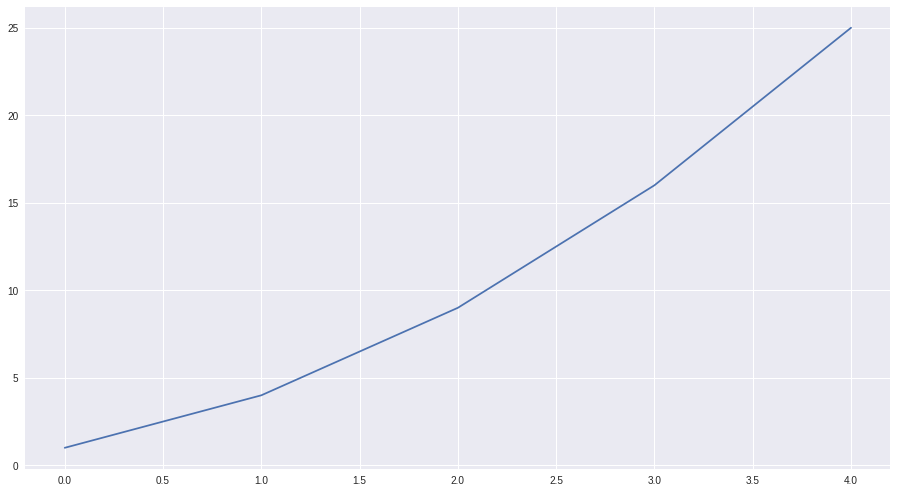

```python
squares = [1,4,9,16,25]
fig,ax = plt.subplots()
fig.set_size_inches(15.5, 8.5)
ax.plot(squares)
plt.show()

#subplots() function can generate one or more plots in the same figure.
#the variable fig represents the entire figure or collection of plots that are generated
#the variable ax represents a single plot in the figure
```

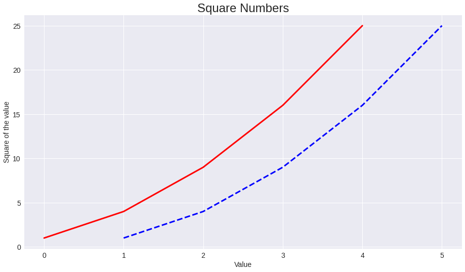

```python
squares = [1,4,9,16,25]
input_values = [1,2,3,4,5]
fig,ax = plt.subplots()
fig.set_size_inches(15.5, 8.5)
ax.plot(squares, linewidth=3,color="red")
#linewidth is the thickness of the line plot() generates
ax.plot(input_values,squares,linewidth=3,color="blue",linestyle="dashed")

#set chart title and label axes
ax.set_title("Square Numbers",fontsize=24)
ax.set_xlabel("Value",fontsize=14)
ax.set_ylabel("Square of the value",fontsize=14)

#setting size of tick labels
ax.tick_params(axis='both',labelsize=14)

plt.show()
```

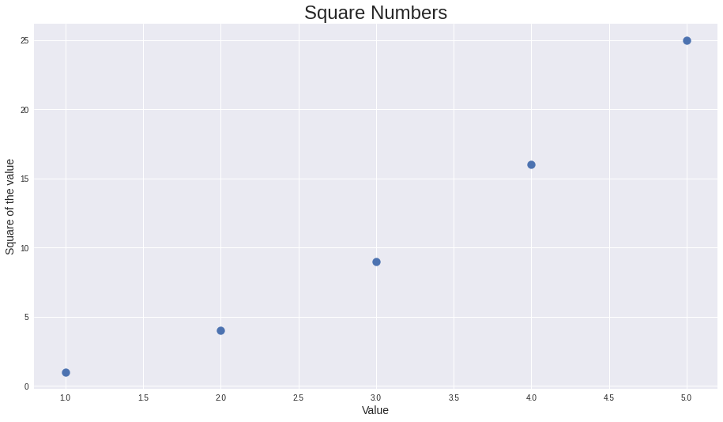

```python
x_values = [1,2,3,4,5]
y_values = [1,4,9,16,25]

fig,ax = plt.subplots()
fig.set_size_inches(15.5, 8.5)
ax.scatter(x_values,y_values,s=100)

ax.set_title("Square Numbers",fontsize=24)
ax.set_xlabel("Value",fontsize=14)
ax.set_ylabel("Square of the value",fontsize=14)

plt.show()
```

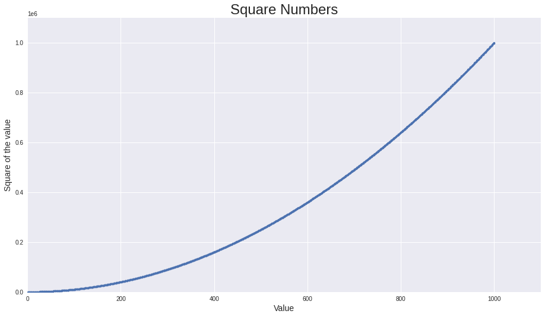

```python
x_values = range(1,1001)
y_values = [x**2 for x in x_values]

fig,ax = plt.subplots()
fig.set_size_inches(15.5, 8.5)
ax.scatter(x_values,y_values,s=10)

ax.set_title("Square Numbers",fontsize=24)
ax.set_xlabel("Value",fontsize=14)
ax.set_ylabel("Square of the value",fontsize=14)

ax.axis([0,1100,0,1100000])

plt.show()
```

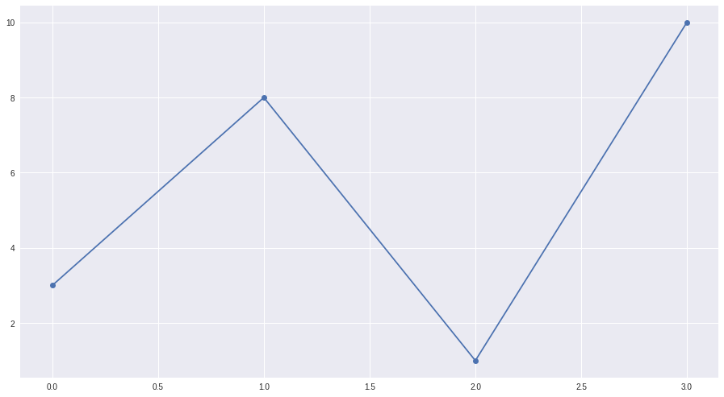

```python
import numpy as np
ypoints = np.array([3, 8, 1, 10])

fig,ax = plt.subplots()
fig.set_size_inches(15.5, 8.5)

ax.plot(ypoints, marker = 'o')#markers = */./+
plt.show()
```

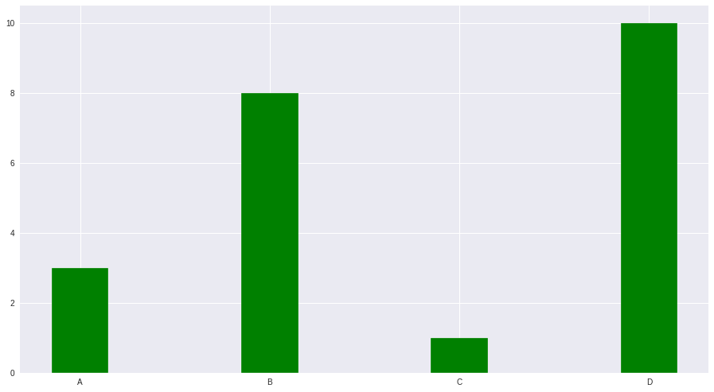

```python
x = np.array(["A", "B", "C", "D"])
y = np.array([3, 8, 1, 10])

fig,ax = plt.subplots()
fig.set_size_inches(15.5,8.5)

ax.bar(x,y,color="green",width=0.3)
plt.show()
```

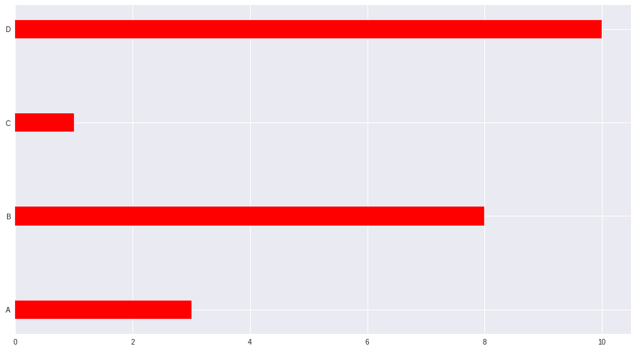

```python
x = np.array(["A", "B", "C", "D"])
y = np.array([3, 8, 1, 10])

fig,ax = plt.subplots()
fig.set_size_inches(15.5,8.5)

ax.barh(x,y,color="red",height=0.2)
plt.show()
```

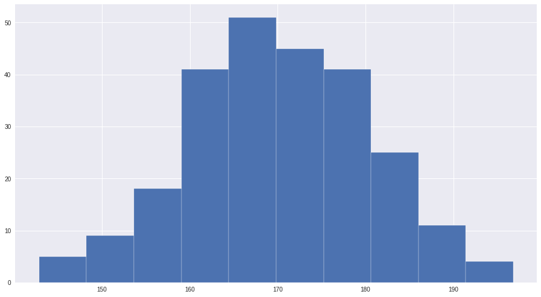

```python
x = np.random.normal(170, 10, 250)

fig,ax = plt.subplots()
fig.set_size_inches(15.5,8.5)

ax.hist(x)
plt.show()
```

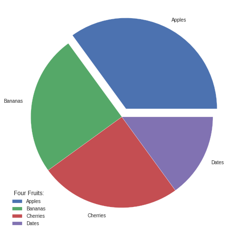

```python
y = np.array([35, 25, 25, 15])
mylabels = ["Apples", "Bananas", "Cherries", "Dates"]
myexplode = [0.1,0,0,0]

fig,ax = plt.subplots()
fig.set_size_inches(15.5,8.5)

ax.pie(y, labels = mylabels,explode=myexplode)
ax.legend(title = "Four Fruits:")
plt.show()
```

# Working with a dataset

## Importing the dataset

```python
import pandas as pd
data = pd.read_csv('https://raw.githubusercontent.com/sureshmanem/Python_LearnByDoing/master/P4-Demographic-Data.csv')
data.head()#test with arguments 1,2,3
```

|  | Country Name | Country Code | Birth rate | Internet users | Income Group |
| --- | --- | --- | --- | --- | --- |
| 0 | Aruba | ABW | 10.244 | 78.9 | High income |
| 1 | Afghanistan | AFG | 35.253 | 5.9 | Low income |
| 2 | Angola | AGO | 45.985 | 19.1 | Upper middle income |
| 3 | Albania | ALB | 12.877 | 57.2 | Upper middle income |
| 4 | United Arab Emirates | ARE | 11.044 | 88.0 | High income |

## Exploratory data analysis

```python
data.tail()#test with arguments 1,2,3
```

|  | Country Name | Country Code | Birth rate | Internet users | Income Group |
| --- | --- | --- | --- | --- | --- |
| 190 | Yemen, Rep. | YEM | 32.947 | 20.0 | Lower middle income |
| 191 | South Africa | ZAF | 20.850 | 46.5 | Upper middle income |
| 192 | Congo, Dem. Rep. | COD | 42.394 | 2.2 | Low income |
| 193 | Zambia | ZMB | 40.471 | 15.4 | Lower middle income |
| 194 | Zimbabwe | ZWE | 35.715 | 18.5 | Low income |

```python
data.info()
```

```
<class 'pandas.core.frame.DataFrame'>
RangeIndex: 195 entries, 0 to 194
Data columns (total 5 columns):
 #   Column          Non-Null Count  Dtype
---  ------          --------------  -----
 0   Country Name    195 non-null    object
 1   Country Code    195 non-null    object
 2   Birth rate      195 non-null    float64
 3   Internet users  195 non-null    float64
 4   Income Group    195 non-null    object
dtypes: float64(2), object(3)
memory usage: 7.7+ KB
```

Print a concise summary of a DataFrame. This method prints information about a DataFrame including the index dtype and columns, non-null values and memory usage.

```python
data.index
```

```
RangeIndex(start=0, stop=195, step=1)
```

```python
#shape of the dataset -> (R,C)
data.shape
```

```
(195, 5)
```

```python
#null entries in each column
data.isnull().sum()
```

```
Country Name      0
Country Code      0
Birth rate        0
Internet users    0
Income Group      0
dtype: int64
```

```python
#unique entries in each column
data.nunique()
```

```
Country Name      195
Country Code      195
Birth rate        177
Internet users    181
Income Group        4
dtype: int64
```

```python
# If you want to check only numerical columns in a more summarised way, drop the include parameter and see the transpose
data.describe(include=None)
```

|  | Birth rate | Internet users |
| --- | --- | --- |
| count | 195.000000 | 195.000000 |
| mean | 21.469928 | 42.076471 |
| std | 10.605467 | 29.030788 |
| min | 7.900000 | 0.900000 |
| 25% | 12.120500 | 14.520000 |
| 50% | 19.680000 | 41.000000 |
| 75% | 29.759500 | 66.225000 |
| max | 49.661000 | 96.546800 |

```python
data.describe(include=None).transpose()
```

|  | count | mean | std | min | 25% | 50% | 75% | max |
| --- | --- | --- | --- | --- | --- | --- | --- | --- |
| Birth rate | 195.0 | 21.469928 | 10.605467 | 7.9 | 12.1205 | 19.68 | 29.7595 | 49.6610 |
| Internet users | 195.0 | 42.076471 | 29.030788 | 0.9 | 14.5200 | 41.00 | 66.2250 | 96.5468 |

```python
## Now, we always have to do a sanity check on the Data we have, we have to check if there are missing values and so on.
data.describe(include = 'all')
```

|  | Country Name | Country Code | Birth rate | Internet users | Income Group |
| --- | --- | --- | --- | --- | --- |
| count | 195 | 195 | 195.000000 | 195.000000 | 195 |
| unique | 195 | 195 | NaN | NaN | 4 |
| top | Ethiopia | NIC | NaN | NaN | High income |
| freq | 1 | 1 | NaN | NaN | 67 |
| mean | NaN | NaN | 21.469928 | 42.076471 | NaN |
| std | NaN | NaN | 10.605467 | 29.030788 | NaN |
| min | NaN | NaN | 7.900000 | 0.900000 | NaN |
| 25% | NaN | NaN | 12.120500 | 14.520000 | NaN |
| 50% | NaN | NaN | 19.680000 | 41.000000 | NaN |
| 75% | NaN | NaN | 29.759500 | 66.225000 | NaN |
| max | NaN | NaN | 49.661000 | 96.546800 | NaN |

```python
## printing the columns/attributes in the pandas dataframe
print(data.columns)
```

```
Index(['Country Name', 'Country Code', 'Birth rate', 'Internet users',
       'Income Group'],
      dtype='object')
```

```python
#elimination of spaces in the attribute names
data.columns = ['CountryName', 'CountryCode', 'BirthRate', 'InternetUsers', 'IncomeGroup']
```

```python
# Birthrate, internet users are continuous variables, and you cannot really look for unique values in these columns,
# however, we can check the unique values in categorical columns such as Incomegroup
pd.unique(data.IncomeGroup)
```

```
array(['High income', 'Low income', 'Upper middle income',
       'Lower middle income'], dtype=object)
```

```python
data['IncomeGroup'].value_counts()
```

```
High income            67
Lower middle income    50
Upper middle income    48
Low income             30
Name: IncomeGroup, dtype: int64
```

```python
data.corr()
```

|  | BirthRate | InternetUsers |
| --- | --- | --- |
| BirthRate | 1.000000 | -0.815589 |
| InternetUsers | -0.815589 | 1.000000 |

```python
# Suppose you want to get only the birthrate as a numpy ndarray or a list
print(type(data.BirthRate))
birthrate = list(data.BirthRate)
```

```
<class 'pandas.core.series.Series'>
```

```python
birthrate[:10]
```

```
[10.244000000000002,
 35.253,
 45.985,
 12.877,
 11.044,
 17.715999999999998,
 13.308,
 16.447,
 13.2,
 9.4]
```

```python
# For a numpy ndarray
birthrate = np.array(data.BirthRate)
```

```python
birthrate[:10]
```

```
array([10.244, 35.253, 45.985, 12.877, 11.044, 17.716, 13.308, 16.447,
       13.2  ,  9.4  ])
```

## Dealing with indexing

```python
data
```

|  | CountryName | CountryCode | BirthRate | InternetUsers | IncomeGroup |
| --- | --- | --- | --- | --- | --- |
| 0 | Aruba | ABW | 10.244 | 78.9 | High income |
| 1 | Afghanistan | AFG | 35.253 | 5.9 | Low income |
| 2 | Angola | AGO | 45.985 | 19.1 | Upper middle income |
| 3 | Albania | ALB | 12.877 | 57.2 | Upper middle income |
| 4 | United Arab Emirates | ARE | 11.044 | 88.0 | High income |
| ... | ... | ... | ... | ... | ... |
| 190 | Yemen, Rep. | YEM | 32.947 | 20.0 | Lower middle income |
| 191 | South Africa | ZAF | 20.850 | 46.5 | Upper middle income |
| 192 | Congo, Dem. Rep. | COD | 42.394 | 2.2 | Low income |
| 193 | Zambia | ZMB | 40.471 | 15.4 | Lower middle income |
| 194 | Zimbabwe | ZWE | 35.715 | 18.5 | Low income |

195 rows × 5 columns

```python
data.set_index(['CountryName'])
```

| CountryName | CountryCode | BirthRate | InternetUsers | IncomeGroup |
| --- | --- | --- | --- | --- |
| Aruba | ABW | 10.244 | 78.9 | High income |
| Afghanistan | AFG | 35.253 | 5.9 | Low income |
| Angola | AGO | 45.985 | 19.1 | Upper middle income |
| Albania | ALB | 12.877 | 57.2 | Upper middle income |
| United Arab Emirates | ARE | 11.044 | 88.0 | High income |
| ... | ... | ... | ... | ... |
| Yemen, Rep. | YEM | 32.947 | 20.0 | Lower middle income |
| South Africa | ZAF | 20.850 | 46.5 | Upper middle income |
| Congo, Dem. Rep. | COD | 42.394 | 2.2 | Low income |
| Zambia | ZMB | 40.471 | 15.4 | Lower middle income |
| Zimbabwe | ZWE | 35.715 | 18.5 | Low income |

195 rows × 4 columns

```python
data.head()
```

|  | CountryName | CountryCode | BirthRate | InternetUsers | IncomeGroup |
| --- | --- | --- | --- | --- | --- |
| 0 | Aruba | ABW | 10.244 | 78.9 | High income |
| 1 | Afghanistan | AFG | 35.253 | 5.9 | Low income |
| 2 | Angola | AGO | 45.985 | 19.1 | Upper middle income |
| 3 | Albania | ALB | 12.877 | 57.2 | Upper middle income |
| 4 | United Arab Emirates | ARE | 11.044 | 88.0 | High income |

```python
data.loc['India']
```

[output not shown]

```python
data.loc[["India", "China", "Japan"] , ["BirthRate", "InternetUsers"]]
```

[output not shown]

```python
data_flexible = data.loc[ : , ["BirthRate", "InternetUsers"]]
```

```python
#this outputs country with lower birth rates and higher no of internet users meaning a more stable and developed nation
data_flexible[(data_flexible['BirthRate']<10) & (data_flexible['InternetUsers']>50)]
```

[output not shown]

```python
data_inc_group = data.groupby(['IncomeGroup'])['BirthRate'].agg(['max', 'min', 'count', 'median', 'mean'])
```

```python
data_inc_group
```

[output not shown]

```python
data_inc_group = data.groupby(['IncomeGroup'])['InternetUsers'].agg(['max', 'min', 'count', 'median', 'mean'])
```

```python
data_inc_group
```

[output not shown]